# Lecture : Probabilities and Frequency Distributions - conclusion (POLS 3316 - Statistics for Political Scientists)

Tom Hanna

### Announcements

- Grading - quiz and problem sets
- Lab changes

  ```
    + More hands on
    + More real data including yours
    + Actually trying things *you* ask about             + This will require using the help files or searching for answers
    + There will be more technical issues
    + Some things may require overnight research
  ```

### Probabilities and Frequence Distributions Conclusion

### Other probability topics

Question 14: I flip a fair coin ten times, the probability that coin comes up heads exactly five times is:

**Let’s look at a simpler example**

Exactly 2 tails out of 3 flips:

S = {TTT,TTH,THT,THH,HTT,HTH,HHT,HHH} - 8 possibilities Possible ways it we can get exactly two tails A = {TTH,THT,HTT} - 3 favorable P(A) = 3/8

If we wanted **at least two tails**: B = {TTT,TTH,THT,HTT} P(B) = 4/8 = 1/2

**For bigger numbers this is too cumbersome to do by hand**

$$\\[4in]$$

There are 10 flips, each with two possible outcomes. which means there are $2^{10}$ possible outcomes. The number of favorable possibilities is the *combinations* that can result in 5 heads, found with the combinations formula for $\binom{n}{r}$ or $\binom{10}{5}$

$$\\[4in]$$

**That yields this cumbersome formula:**

$\frac{10!}{(5!)^2 * 2^{10}}$

This can be rewritten as this:

$\frac{10*9*8*7*6*5*4*3*2*1}{(5*4*3*2*1)*(5*4*3*2*1)*2^{10}}$

which simplifies to

$\frac{10*9*8*7*6}{(5*4*3*2*1)*2^{10}}$

```r
(10*9*8*7*6*5*4*3*2*1)/((5*4*3*2*1)^2 * 2^10)
```

```
## [1] 0.2460938
```

```r
(10*9*8*7*6)/((5*4*3*2*1)*2^10)
```

```
## [1] 0.2460938
```

$$\\[4in]$$

**If you see a test question on this, I would expect you to be able to:**

- Identify if there is a combination vs permutation
- Identify if it is with or without repetition
- Complete a very simple example using sets, i.e. exactly 2 tails out of 3 flips.
- Set up the problem without completing it. For example you might answer:

  ```
   + Narrative: The answer to this problem would be figured by dividing the combination 10 choose 5 by the number of possible outcomes, which is 2 to the tenth power
   + Formula: $\frac{\binom{n}{r}}{2^{10}}$
   + Narrative: The favorable outcomes are a combination choosing 5 from 10 and the possible outcomes are $2^10$
   + Narrative: I would use a combination to find the favorable outcomes and use 2^10 as the total possible outcomes
  ```

- Solving a *permutation* question may be bonus material

If you would like to have more fun with this or if you intend to take the GRE, here are some sources.

https://www.mathsisfun.com/combinatorics/combinations-permutations.html

https://statisticsbyjim.com/probability/permutations-probabilities/

https://www.khanacademy.org/math/precalculus/x9e81a4f98389efdf:prob-comb/x9e81a4f98389efdf:prob-combinatorics-precalc/e/probability_with_perm_comb

$$\\[4in]$$

### Types of variables

- Continuous - numbers with decimal places
- Discrete - whole numbers or integers
- Categorical - numbers just represent categories

  ```
    + Ordinal - ordered highest to lowest
    + Nominal - no particular order
  ```

$$\\[4in]$$

### Probability Distribution Functions

- Two meanings of function - both apply

  ```
    + Mathematical "function" - a mathematical operation or equation - *f(x)* or *g(x)*
    + R "function" - sets of instructions - mean(x) + pnorm(x)
  ```

- Probability mass function (PMF) - discrete variables
- Probability density function (PDF) - continuous variables

  ```
    + Both have the same objective
    + Probability a random variable is exactly equal to some specific value
    + PDF can not give a specific value
    + PDF - integral over a range (calculus)
    + R does the PDF for us - *dnorm()* for normal, *dbinom()* for binomial, *dpois()* for Poisson and 17 or so others...
  ```

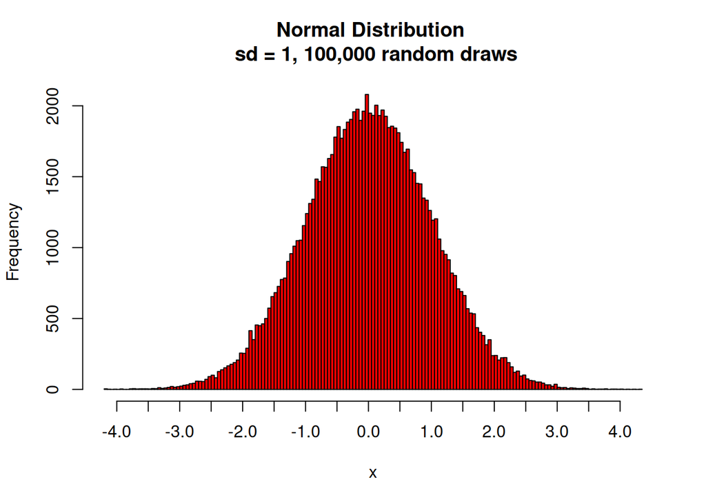

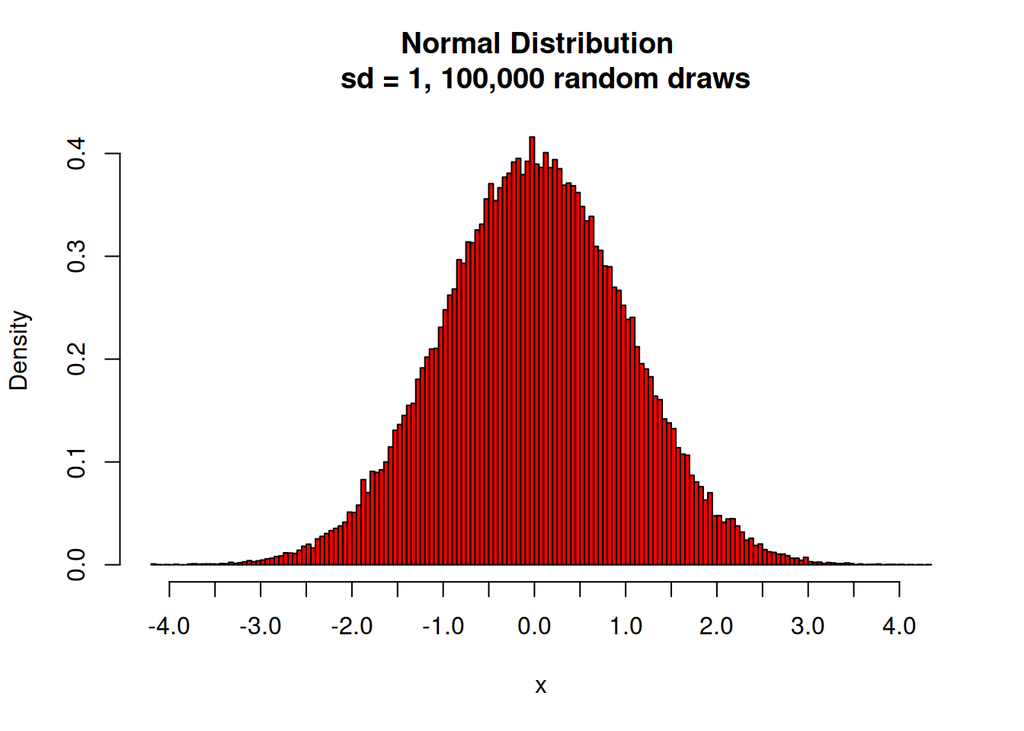

$$\\[4in]$$
+ Cumulative distribution function (CDF)

```
    + Gives the probability of finding the random variable at a value less than or equal to a a specific point.
    + R does the CDF for us *pnorm()* for normal, *pbinom()* for binomial, *punif()* for uniform and 17 or so others.
```

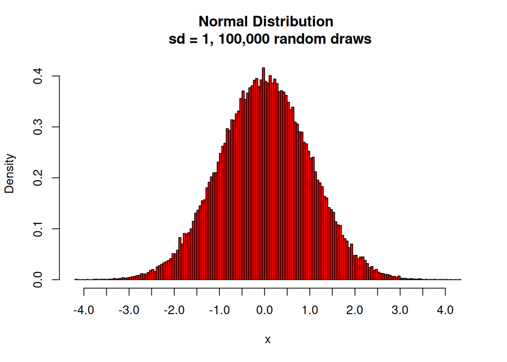

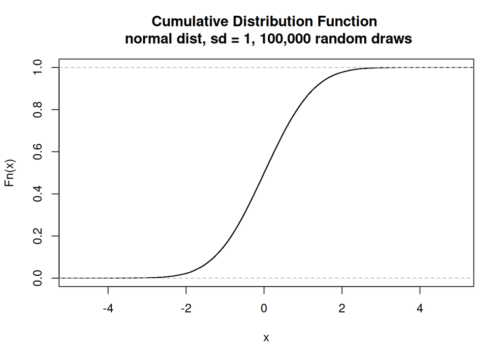

** Related R functions

- Similar commands for other distributions than normal
- Quantiles (percentiles, deciles, etc.) - qnorm()

  ```
    + Works the opposite of pnorm()
    + pnorm() tells us the probability for a value
    + qnorm() tells us the value for a probability
  ```

- Random number generation - rnorm()

  ```
    + Generates *n* random numbers from a normal distribution
    + The more we create the more that it will look like that bell curve
    + **The Law of Large Numbers**
  ```